# Floer Homology

We have the following situation:

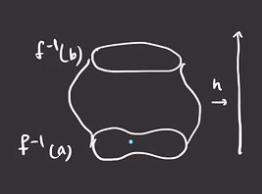

image_2021-01-21-12-11-16

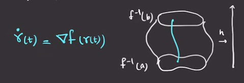

image_2021-01-21-12-12-42

For technical reasons, we want to end up with cohomology instead of homology and will take $-\nabla f$ instead of $\nabla f$ everywhere:

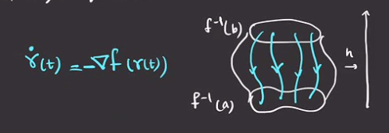

image_2021-01-21-12-13-35

So $\gamma$ will be a trajectory of $- \nabla f$, and $f ^{-1} [a, b] \cong f ^{-1} (a) \times[0, 1]$. A problem is that following these trajectories may involve arriving at $f ^{-1} (a)$ at different times:

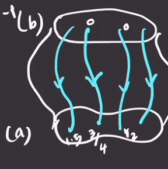

image_2021-01-21-12-15-10

We can fix this by normalizing:
$$\begin{align*}
V \mathrel{\vcenter{:}}=- \nabla f / {\left\lVert { \nabla f} \right\rVert}^2 \implies (df)(v) = {\left\langle { \nabla f},~{ - \nabla f / {\left\lVert {\nabla f} \right\rVert}^2} \right\rangle} = -1
.\end{align*}$$

For every $p \in f ^{-1} (b)$, if $\gamma(t)$ is the trajectory starting from $p$, i.e. $\gamma(0) = p$, then $\gamma(b-a) \in f ^{-1} (a)$. So define
$$\begin{align*}
\Phi: f ^{-1} (b) \times[0, b-a] &\to f ^{-1} ([a, b]) \\
(p, t) &\mapsto \gamma_p (t)
,\end{align*}
which will be a diffeomorphism.$$

Suppose $f ^{-1} ([a, b])$ contains exactly one critical point $p$ with $\mathop{\mathrm{Ind}}(p) = \lambda$ and $f(p) = c$. Then
$$\begin{align*}
M_b = M_a \cup_{{{\partial}}} \qty{ D^ \lambda \times D^{n - \lambda} }
\end{align*}
where \(n \mathrel{\vcenter{:}}=\dim M\).$$

For $\lambda= 1, n - \lambda= 2$:

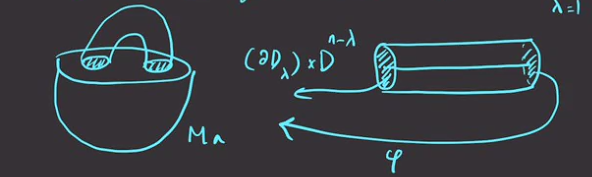

image_2021-01-21-12-32-38

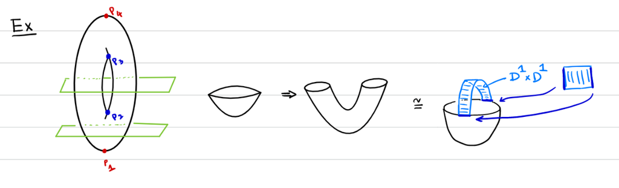

image_2021-01-19-00-53-07

$$\begin{align*}
W_f^u(p) \mathrel{\vcenter{:}}=\left\{{p}\right\} \cup\left\{{
\dot{\gamma(t)} = -\nabla f(\gamma(t)),\, \lim_{t\to -\infty} \gamma(t) = p,\, t\in {\mathbb{R}}
}\right\}
.\end{align*}$$

If $\mathop{\mathrm{Ind}}(p) = \lambda$ then $W_f^u(p) \cong {\mathbb{R}}^ \lambda$.

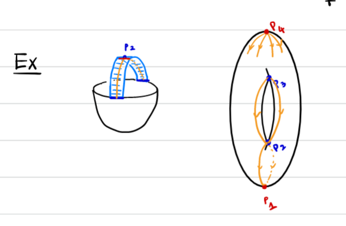

image_2021-01-19-00-55-24

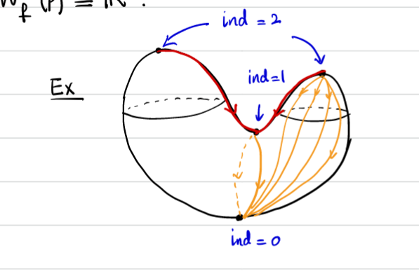

image_2021-01-19-00-55-41

$$\begin{align*}
W_f^s(p) \mathrel{\vcenter{:}}=\left\{{p}\right\} \cup\left\{{
\dot{\gamma(t)} = -\nabla f(\gamma(t)),\, \lim_{t\to +\infty} \gamma(t) = p,\, t\in {\mathbb{R}}
}\right\}
.\end{align*}$$

If $\mathop{\mathrm{Ind}}(p) = \lambda$ then $W_f^s(p) \cong {\mathbb{R}}^{n- \lambda}$.

And a basis for open neighborhoods around $p$ is given by
$$\begin{align*}
N_g(f) = \left\{{
g:M\to {\mathbb{R}}{~\mathrel{\Big|}~}
{\left\lvert {
{\frac{\partial ^k g}{\partial {\partial}x _{i_1} \cdots {\partial}x _{i_k} }\,}(p)
-
{\frac{\partial ^k f}{\partial {\partial}x _{i_1} \cdots {\partial}x _{i_k} }\,}(p)
} \right\rvert} < \infty\, \forall \alpha,\, \forall p\in h_ \alpha(C_ \alpha)
}\right\}
.\end{align*}$$

The set of Morse functions on $M$ is open and dense in $C^ \infty (M; {\mathbb{R}})$.

# 4 Bibliography

[^1]: See Sarkour-Wang
[^2]: This is the strongest variant.
[^3]: What does “detect” mean? This is slightly technical.
[^4]: Note that wedging to a nontrivial top form is equivalent to being nowhere integrable here.
[^5]: These are referred to as **Seifert surfaces**.